# Projet prévision sur série chronologique par modèle SARIMA

Clovis Deletre

Charles Vitry

# Introduction

Dans le cadre de ce projet, nous souhaitons **modéliser par un processus** une série temporelle de données.

Ici, la série concerne les ventes de champagne de janvier 1962 à septembre 1970, avec une observation par mois.

L’ambition est de pouvoir effectuer une **prévision** sur les 12 dernières observations grâce à une modélisation sur le reste des données.

## Importation des données

On importe les données, puis on en affiche un résumé.

```r
data <- read_delim("data.csv", delim = ";", col_types = cols(date = col_date(format = "%d/%m/%Y")),
    trim_ws = TRUE)
summary(data)
```

```
##       date                value
##  Min.   :1962-01-01   Min.   :  718
##  1st Qu.:1964-03-01   1st Qu.: 3086
##  Median :1966-05-01   Median : 4217
##  Mean   :1966-05-01   Mean   : 4734
##  3rd Qu.:1968-07-01   3rd Qu.: 5221
##  Max.   :1970-09-01   Max.   :13916
```

Vérifions l’hypothèse d’**homogéneité de la variance** au cours des années avec le test de bartlett

```r
data$date[1:93] %>%
  format(format = "%Y") %>%
  bartlett.test(data$value[1:93], .)
```

```
##
##  Bartlett test of homogeneity of variances
##
## data:  data$value[1:93] and .
## Bartlett's K-squared = 15.224, df = 7, p-value = 0.03323
```

Avec une p-valeur de 0.03, l’hypothèse H0 de l’homogénéité de la variance au cours des années est rejeté.

> Nous aurions pu envisager une transformation de Box-cox.

*Préparons nos données*

1. On transforme la base en série temporelle avec la fonction ts() de R.
2. On précise la fréquence de la série (ici mensuelle) et la date de début de la série.
3. On divise la série en deux parties : une partie d’apprentissage et une partie de test.

```r
data_ts <- ts(data[,2], start = 1962, frequency = 12)

data_ts_train <- window(data_ts, start = c(1962, 1), end = c(1969, 9))
data_ts_test <- window(data_ts, start = c(1969, 10), end = c(1970, 9))
```

Affichage de la série

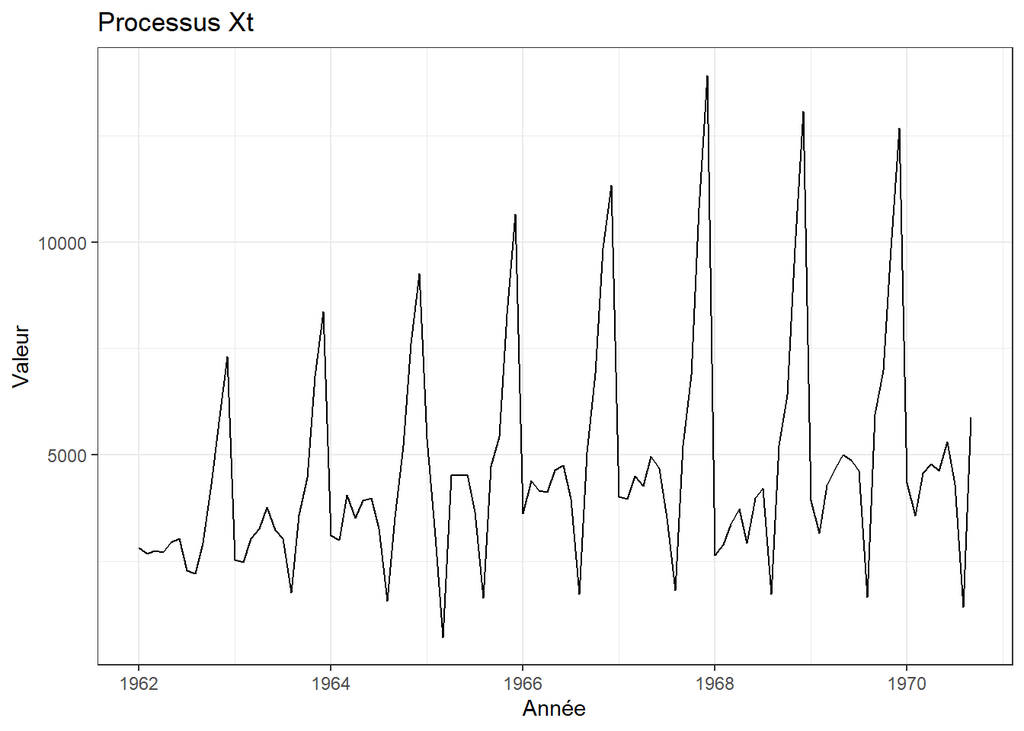

# Phase d’identification a priori du modèle

Nous avons 105 observations à notre disposition ce qui est peu, nous rechercherons donc minimiser le nombre de paramètres à estimer afin de s’assurer de la robustesse de ceux-ci.

Un modèle SARIMA est définit comme suit

$$\Phi_p(B) \nabla^d \quad \Phi_P(B^S)\nabla^D_S \quad X_t = \Theta_q(B)
\Theta_Q(B) \mathcal{E}_t$$

Pour $1 \leq t \leq T$, les $X_t$ sont nos observations, et nos $\mathcal{E}_t$ sont des bruits blancs.

Définissons les paramètres des autres composants par étapes.

## Opérateur Nabla

La série temporelle doit être un processus stationnaire si nous voulons la modéliser par un sarima.

Pour observer cela, on décompose la série temporelle en tendance, en saisonnalité et en bruit.

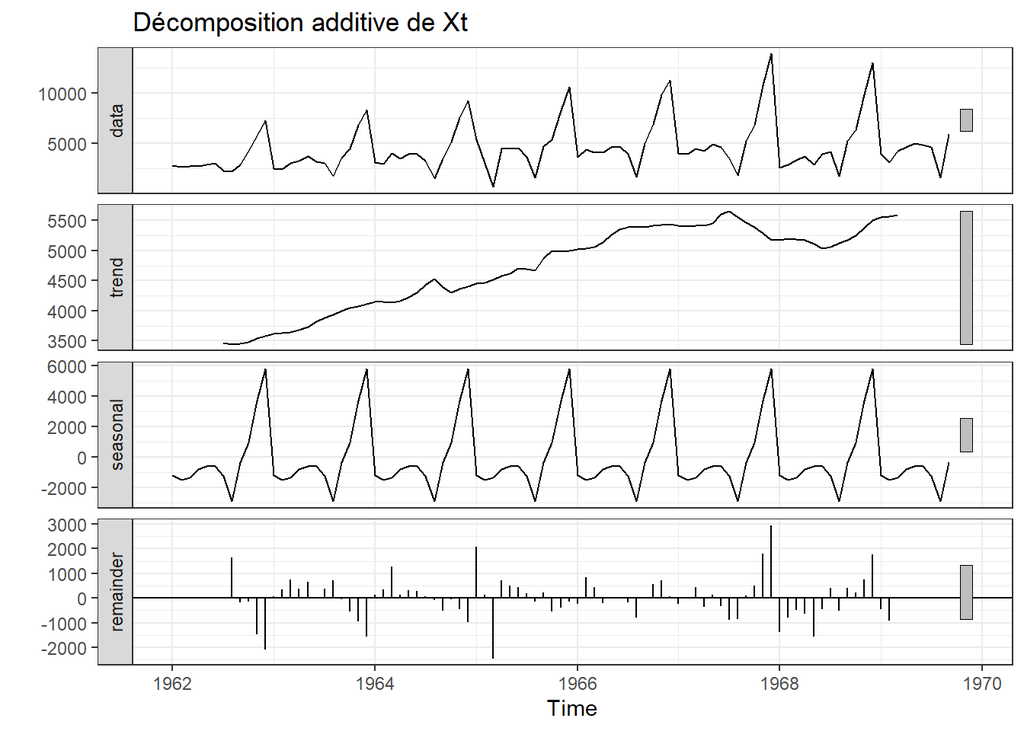

```r
decompose(data_ts_train) %>%
  autoplot(main = "Décomposition additive de Xt")
```

> on remarque une **forte saisonnalité** (ici annuelle) et une **tendance**

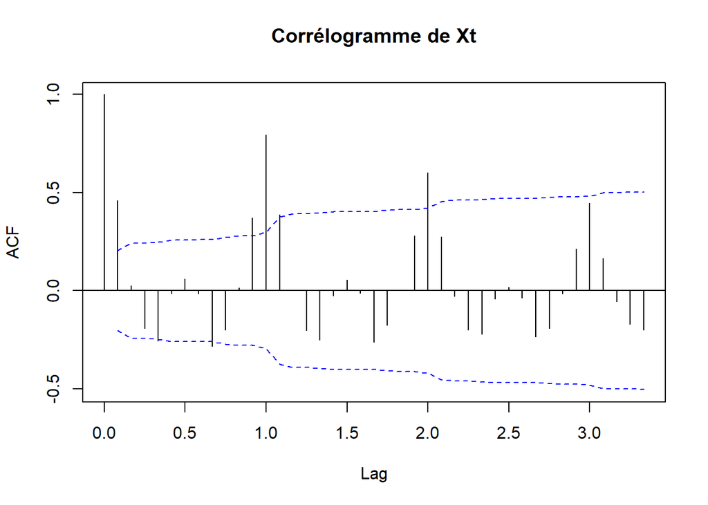

```r
acf(data_ts_train, lag.max = 40, main = "Corrélogramme de Xt", ci.type = "ma")
```

Les autocorrélations sont fortes pour les $\rho (h)$ dont les h sont des multiples de 12. Il s’agit d’une **saisonnalité annuel** donc.

Pour traiter cette saisonnalité annuel, on **differencie** une première fois en saisonnalité par l’application de l’opérateur $\nabla ^{12} = 1 - B^{12}$ aux données.

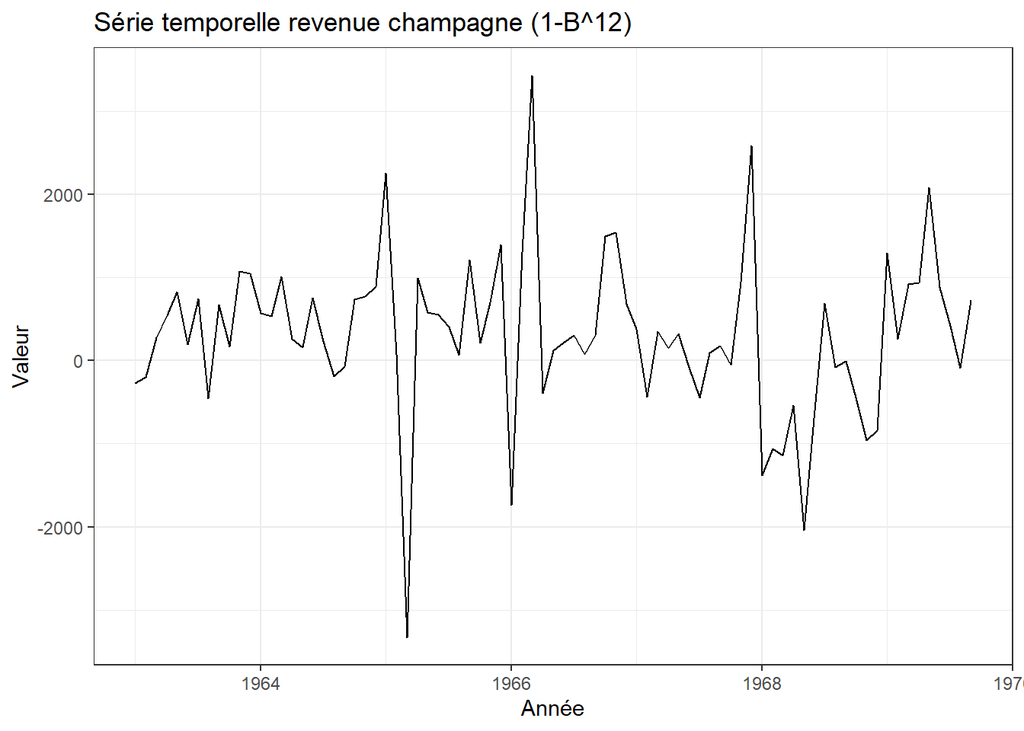

```r
data_diff12 <- diff(data_ts_train, 12)

autoplot(data_diff12, main = "Série temporelle revenue champagne (1-B^12)", xlab = "Année", ylab = "Valeur")
```

On décompose la série temporelle différenciée pour l’analyser.

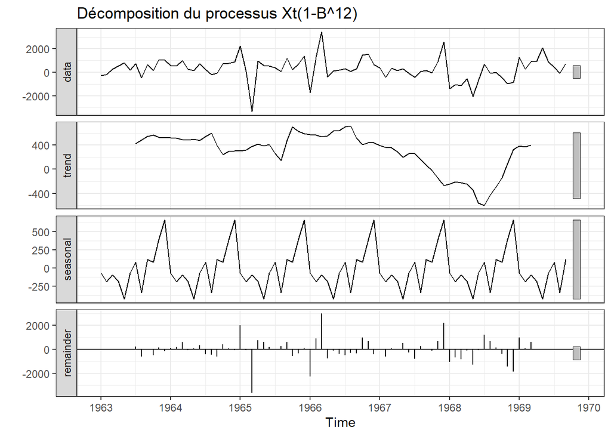

```r
decompose_diff12 <- decompose(data_diff12)
autoplot(decompose_diff12 , main = "Décomposition du processus Xt(1-B^12)")
```

Après application de l’opérateur $\nabla ^{12}$ on observe que cela n’a pas été suffisant pour éliminer complétement la saisonnalité.

De plus, on observe la disparition de la tendance, cela est dû à la présence du facteur $1 - B$ dans la formule de l’opérateur nabla en saisonnalité.

$$\nabla ^{12} = 1 - B^{12} = (1 -
B)P(B)$$
Vérifions la disparition de la tendance par le test de Mann-Kendall

```r
MannKendall(data_diff12)
```

```
## tau = -0.0954, 2-sided pvalue =0.20906
```

Avec une p-valeur de 0.209, l’hypothèse H0 “*il n’y a aucune tendance*” n’est pas rejeté. Tandis que l’hypothèse alternative H1 “*il y a une tendance*” est rejeté.

Nous avons stationnariser la série et n’appliquerons donc pas un second opérateur nabla sur les données.

Nous avons pu éliminer la tendance, ce qui est positif pour notre modèle. Mais cela induit une augmentation de **l’hétérogénéité de** **la variance** qui est elle négative pour notre modélisation.

Quantifions l’augmentation en effectuant à nouveau un test d’homogénéité de la variance entre les années.

```r
df_diff12 <- data.frame(Y=data_diff12, date=round(time(data_diff12)))
bartlett.test(df_diff12$value, df_diff12$date)
```

```
##
##  Bartlett test of homogeneity of variances
##
## data:  df_diff12$value and df_diff12$date
## Bartlett's K-squared = 22.826, df = 7, p-value = 0.001828
```

La dégradation est significative, nous sommes passés d’une p-valeur de 0.03 à 0.001. C’est à dire, d’une probabilité d’homogénéité de la variance entre les années de 3% à 0.1%.

## Estimation paramètres p, q, P, Q

Après estimation de nos paramètres d & D, estimons p et q (P et Q pour la saisonnalité).

Pour trouver la valeur du paramètre **q**, on regarde le **corrélograme** (autocorrélation) de nos données puisque $\forall h > q ,\rho (h) = 0$ , ce qui correspond à $\hat{\rho} (h) \in [interval de Bartlett]$ . Puisque nous ne pouvons que estimer les $\rho (h)$. A noter que l’interval de Bartlett n’est pas constant.

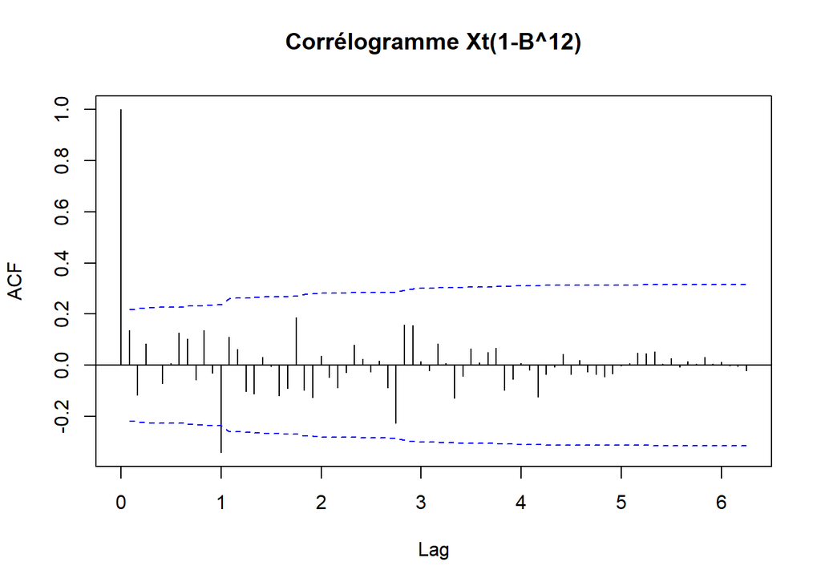

```r
acf(data_diff12, lag.max = 75, main = "Corrélogramme Xt(1-B^12)",ci.type = "ma")
```

D’après le corrélograme de $(1 - B^{12})Xt$ on remarque que le processus présente une autocorrélation fortement significative en $\hat{\rho} (12)$

Par la corrélation significative de $\hat{\rho} (12)$, nous pourions implémenter un $MA_{12}(1)$ dans notre modèle SARIMA. Un $MA(12)$ n’était pas envisageable car cela induirait l’estimation de 12 paramètres, ce qui est impossible compte tenu du nombre d’observations.

Voyons s’il est plus judicieux d’implémenter une partie autoregressive.

Pour trouver la valeur du paramètre **p**, on regarde la **fonction d’autocorrélation partielle** **estimée** de notre série différencié puisque $\forall h > p ,r(h) = 0$ , ce qui correspond à $\hat{r} (h) \in [interval de Quenouille]$ . Puisque nous ne pouvons que estimer les $r(h)$

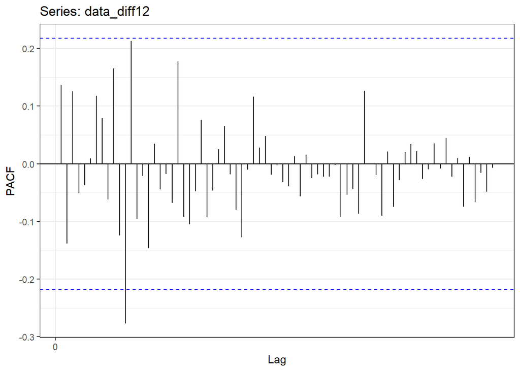

```r
pacf(data_diff12, lag.max = 75, main = "Fonction d'autocorrélation partielle Xt(1-B^12)") %>%
  autoplot()
```

D’après la fonction d’autocorrélation partielle de $(1 - B^{12})Xt$ on remarque que le processus présente une autocorrélation partielle fortement significative en $\hat{r} (12)$

Par la corrélation significative de $\hat{r} (12)$, nous pourions implémenter un $AR_{12}(1)$ dans notre modèle SARIMA. Un $AR(12)$ n’était pas envisageable car cela induirait l’estimation de 12 paramètres, ce qui est impossible compte tenu du nombre d’observations (estimations peu robustes).

Nous sommes face à un dilemne, soit nous implémentons un terme $MA_{12}(1)$ soit un terme $AR_{12}(1)$, sachant que les valeurs sont toute deux significatives. Pour trancher, regardons les modèles associés :

*Implémentation d’un terme* $MA_{12}(1) => SARIMA_{12}[(0,0,0),(0,1,1)]$
$$(1 -
B^{12}) Xt = (1- \theta_{12}B^{12})\mathcal{E}_t$$

*Implémentation d’un terme* $AR_{12}(1) => SARIMA_{12}[(0,0,0),(1,1,0)]$
$$(1 -
B^{12})(1 - \varphi_{12}B^{12})Xt = \mathcal{E}_t$$

Création de notre premier modèle

```r
model1 <- arima(data_ts_train, order = c(0,0,0), seasonal = list(order = c(0,1,1), period = 12))
model1
```

```
##
## Call:
## arima(x = data_ts_train, order = c(0, 0, 0), seasonal = list(order = c(0, 1,
##     1), period = 12))
##
## Coefficients:
##          sma1
##       -0.1934
## s.e.   0.0956
##
## sigma^2 estimated as 964549:  log likelihood = -673.23,  aic = 1350.46
```

Vérifions que la série des résidus $\hat{\mathcal{E}_t}$ est cohérente avec l’hypothèse selon laquelle $\mathcal{E}_t$ est un bruit blanc grâce au test de Ljung-Box, il s’agit d’un équivalent du test Portmanteau (un khi²)

```r
Box.test(model1$residuals, lag = 12, type = "Ljung-Box")
```

```
##
##  Box-Ljung test
##
## data:  model1$residuals
## X-squared = 12.831, df = 12, p-value = 0.3815
```

Avec un p-valeur de 0.38, l’hypothèse H0 “*les résidus sont corrélés*” n’est pas rejeté, tandis que l’hypothèse H1 “*les résidus sont non corrélés*” est rejeté. Le test est peu significatif, **recherchons un terme simple à rajouter à notre modèle**.

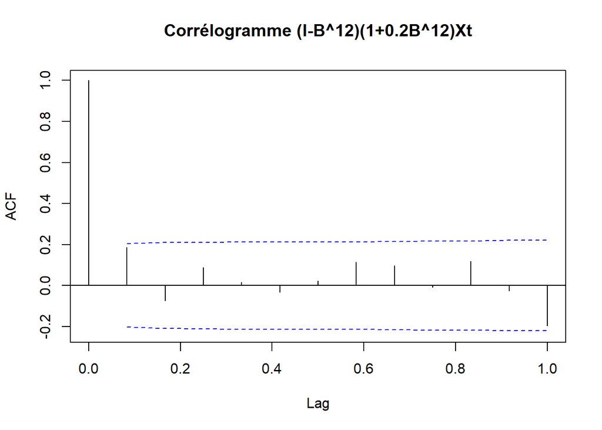

```r
acf(model1$residuals, lag.max = 12, main = "Corrélogramme (I-B^12)(1+0.2B^12)Xt",ci.type = "ma")
```

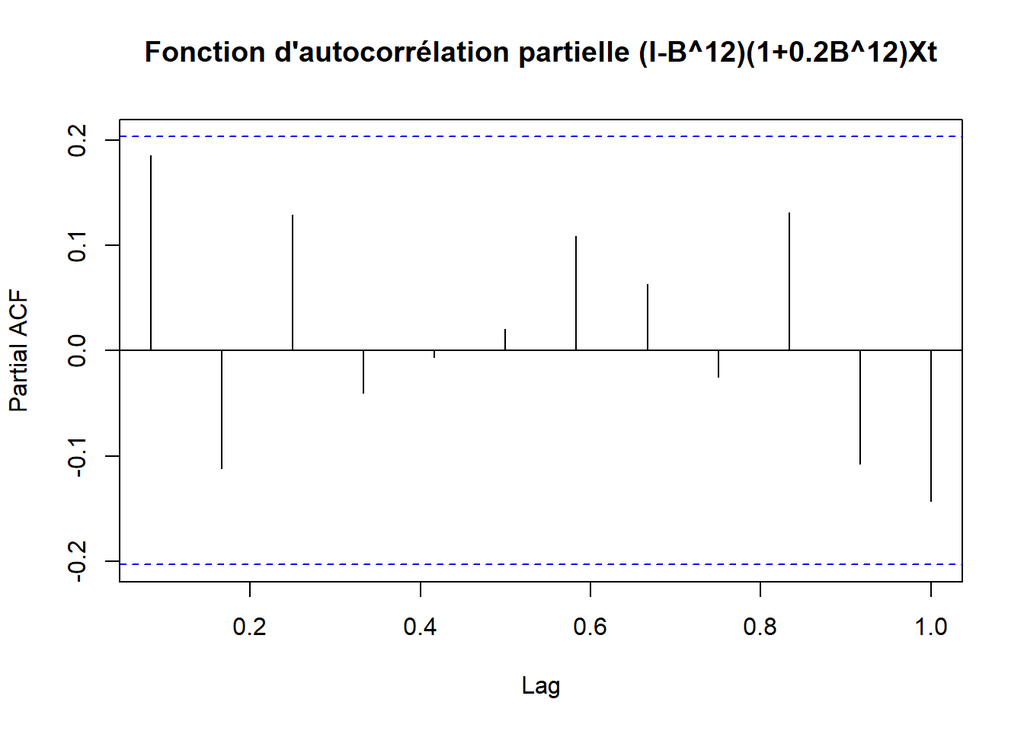

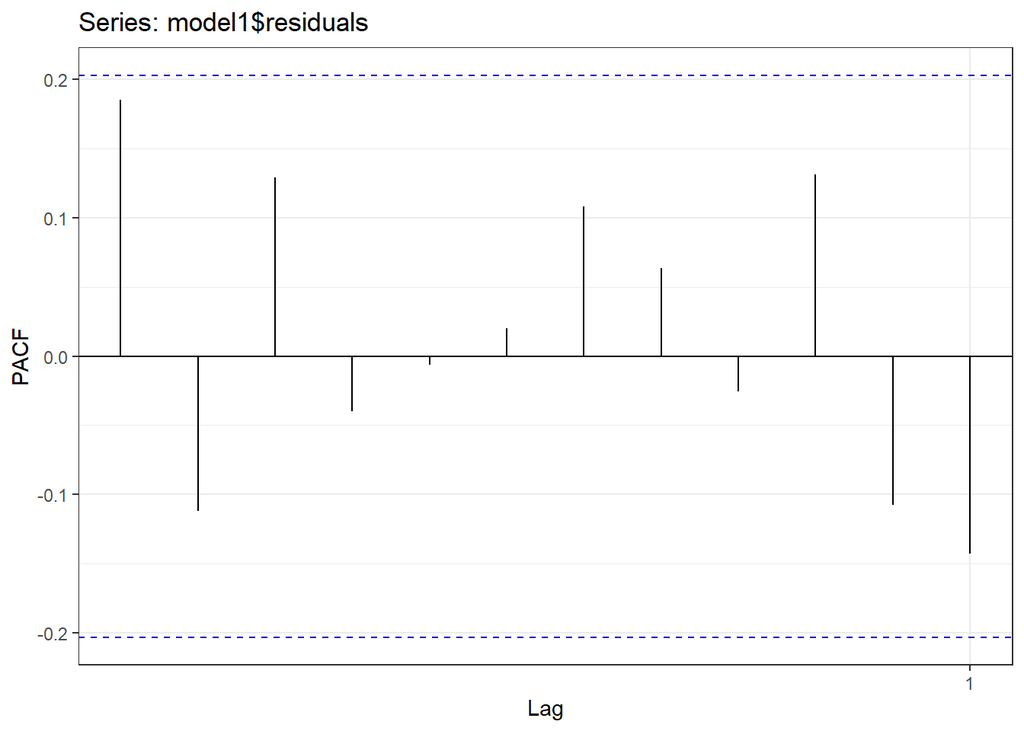

```r
pacf(model1$residuals, lag.max = 12, main = "Fonction d'autocorrélation partielle (I-B^12)(1+0.2B^12)Xt") %>%
  autoplot()
```

# Estimation des paramètres du modèle

Notre modèle SARIMA est définit tel que
$$SARIMA_{12}[(0,0,1),(1,1,0)]$$
$$(1 - B^{12})(1 - \varphi_{12}B^{12})Xt = (1-
\theta_{1}B^{1})\mathcal{E}_t$$

```r
model2 <- arima(data_ts_train, order = c(0,0,1), seasonal = list(order = c(1,1,0), period = 12))
model2
```

```
##
## Call:
## arima(x = data_ts_train, order = c(0, 0, 1), seasonal = list(order = c(1, 1,
##     0), period = 12))
##
## Coefficients:
##          ma1     sar1
##       0.3578  -0.3361
## s.e.  0.1115   0.1064
##
## sigma^2 estimated as 841116:  log likelihood = -668.24,  aic = 1342.48
```

Le paramètre de l’AR(1) de saisonnalité 12 est estimé à -0.34 Et le paramètre du MA(1) est estimé à 0.36. Avec des écart-types respectifs de 0.11 et 0.10

# Tests statistiques

## Significativité des coefficients

On test la significativité des coffecients de notre ARIMA.
$$\left\{
\begin{array}{ll}
coefficient = 0 & \mbox{(H0)} \\
coefficient \ne 0 & \mbox{(H1)}
\end{array}
\right.$$

```r
require(lmtest)
coeftest(model2)
```

```
##
## z test of coefficients:
##
##      Estimate Std. Error z value Pr(>|z|)
## ma1   0.35775    0.11152  3.2080 0.001336 **
## sar1 -0.33607    0.10643 -3.1576 0.001591 **
## ---
## Signif. codes:  0 '***' 0.001 '**' 0.01 '*' 0.05 '.' 0.1 ' ' 1
```

Le test est hautement signficatif, on rejete H0 *“les coefficients sont nulles”* et on ne rejete pas H1 *“les coefficients sont non nulles”*.

## Test des résidus

Vérifions que la série des résidus $\hat{\mathcal{E}_t}$ est cohérente avec l’hypothèse selon laquelle $\mathcal{E}_t$ est un bruit blanc grâce au test de Ljung-Box, il s’agit d’un équivalent du test Portmanteau (un khi²)

```r
Box.test(model2$residuals, lag = 12, type = "Ljung-Box")
```

```
##
##  Box-Ljung test
##
## data:  model2$residuals
## X-squared = 5.7129, df = 12, p-value = 0.9299
```

Avec un p-valeur de 0.93, l’hypothèse H0 “*les résidus sont corrélés*” n’est pas rejeté, tandis que l’hypothèse H1 “*les résidus sont non corrélés*” est rejeté. Le test est hautement significatif.

Vérification visuel

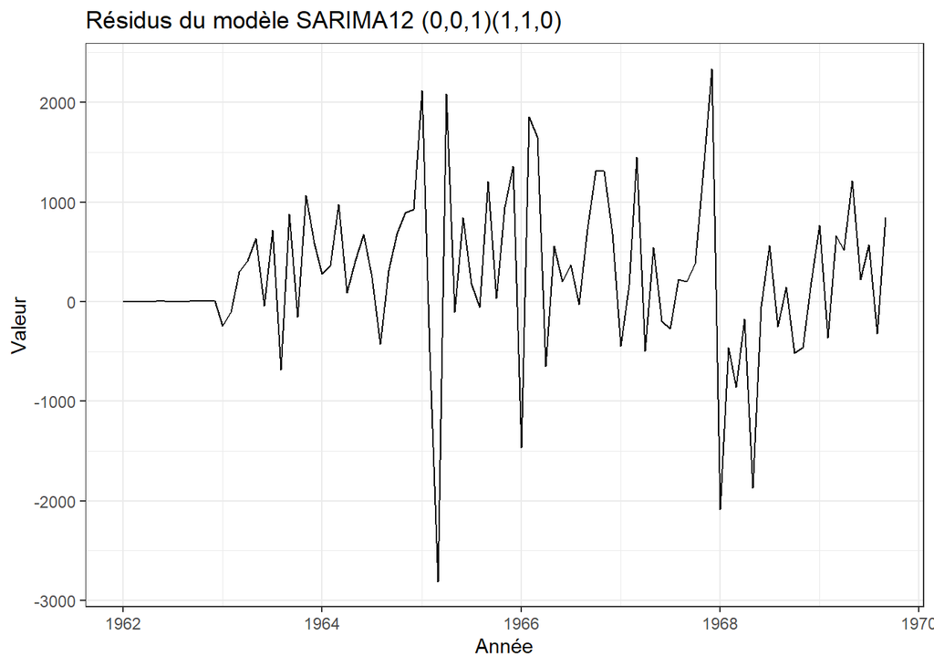

```r
autoplot(model2$residuals, main = "Résidus du modèle SARIMA12 (0,0,1)(1,1,0)", xlab = "Année", ylab = "Valeur")
```

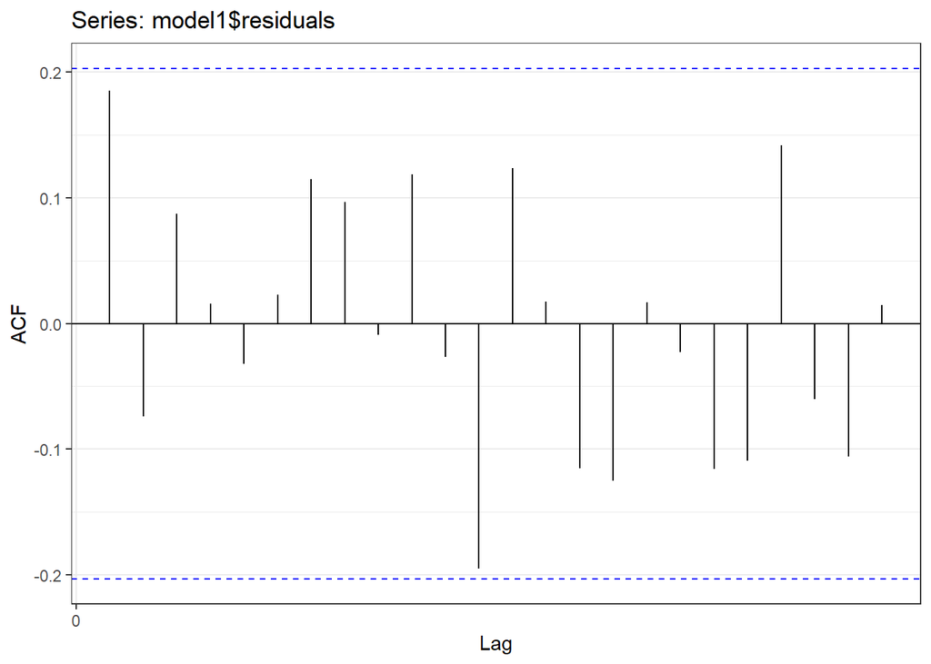

```r
acf(model1$residuals, lag.max = 24, main = "ACF des résidus du modèle SARIMA12 (0,0,1)(1,1,0)", ci.type = "ma") %>%
  autoplot()
```

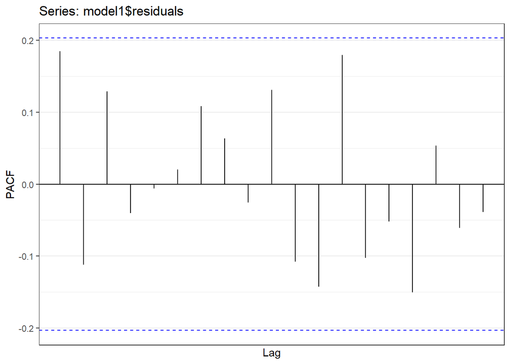

```r
pacf(model1$residuals, main = "PACF des résidus du modèle SARIMA12 (0,0,1)(1,1,0)") %>%
  autoplot()
```

## Prédiction sur la série temporelle de test

Nous avons entrainé notre modèle sur l’ensemble des données excepté la dernière année, prédisons cette dernière avec notre modèle.

```r
pred = predict(model1, 12)
data$predict = c(rep(NA,93) , pred$pred )
names(data) = c("date","Xt","prédiction du modèle SARIMA")
```

Affichage de la prédiction

```r
don=xts( x=data[,-1], order.by=data$date)

p <- dygraph(don, main = "Affichage de la présivion par modèle SARIMA",ylab = "Revenue vente de champagne") %>%
  dyOptions(labelsUTC = TRUE, fillGraph=TRUE, fillAlpha=0.1) %>%
  dyRangeSelector() %>%
  dyCrosshair(direction = "vertical") %>%
  dyHighlight(highlightCircleSize = 5, highlightSeriesBackgroundAlpha = 1)
p
```

[interactive chart not shown]

# Choix d’un modèle

On vérifie nos résultats aves les mesures suivantes :

> MAPE : Mean Absolute Percentage Error MAE : Mean Absolute Error MSE : Mean Squared Error RMSE : Root Mean Squared Error

```r
MAPE <- mape(data_ts_test, pred$pred)
MAE <- mae(data_ts_test, pred$pred)
MSE <- mse(data_ts_test, pred$pred)
RMSE <- rmse(data_ts_test, pred$pred)

MAPE
```

```
## [1] 0.07349358
```

```r
MAE
```

```
## [1] 332.4839
```

```r
MSE
```

```
## [1] 144202.1
```

```r
RMSE
```

```
## [1] 379.7396
```